# University of Chicago Police Department Open Data Analysis

# 1 Introduction

UCPD releases three types of data on their data page. This data is not directly downloadable and was web scraped into a database which was then standardized. The three types of data include *[The Daily Incident Report](https://incidentreports.uchicago.edu/)*, which includes crimes and fires reported to UCPD in its patrol area, *[Traffic Stops](https://incidentreports.uchicago.edu/trafficStops.php)*, and *[Field Interviews](https://incidentreports.uchicago.edu/fieldInterviews.php)*.

# 2 Summary

*Data includes 2015-01-01 to 2022-06-30.*

The University of Chicago Police Department (UCPD) polices about 3.5 square miles of Chicago’s south side. About 50,000 Chicagoans, of which about 50% are African American, live permanently in their patrol area. UCPD’s data shows that African Americans are stopped, searched, and cited at rates higher than any other racial group. Including that:

- Since 2015, **73.4% of traffic stops and 92.9% of street interviews** UCPD conducted were with African Americans
- During traffic stops, African Americans received citations at almost double the rate of non-African Americans **(15.3% vs. 8.4%)**
- UCPD searches **1 out of 39** African American drivers it stops, compared to **1 out of 211** non-African Americans motorists, with **93.7%** of all vehicle searches conducted on African Americans
- Half of all searches conducted on African Americans ended without a citation
- 36 out of 37 traffic stop searches in 2019 were conducted on African American drivers
- In 2019, African Americans were cited at 10.8% and non-African Americans were cited at 6.0%

## 2.1 Last 365 Days

For the last 12 months of data which range from 2021-06-30 to 2022-06-30.

- For the last 12 months, there have been 870 traffic stops. 641 drivers were African American (74%).
- For the last 12 months, there have been 55 interviews. 48 of the interviewed were African American (87%).
- For the last 12 months, UCPD has searched 12 drivers. 10 were African American (83%).
- For the last 12 months, UCPD has issued 163 citations. 135 were issued to African American drivers (83%).

# 3 Dashboard Overview of Police Actions

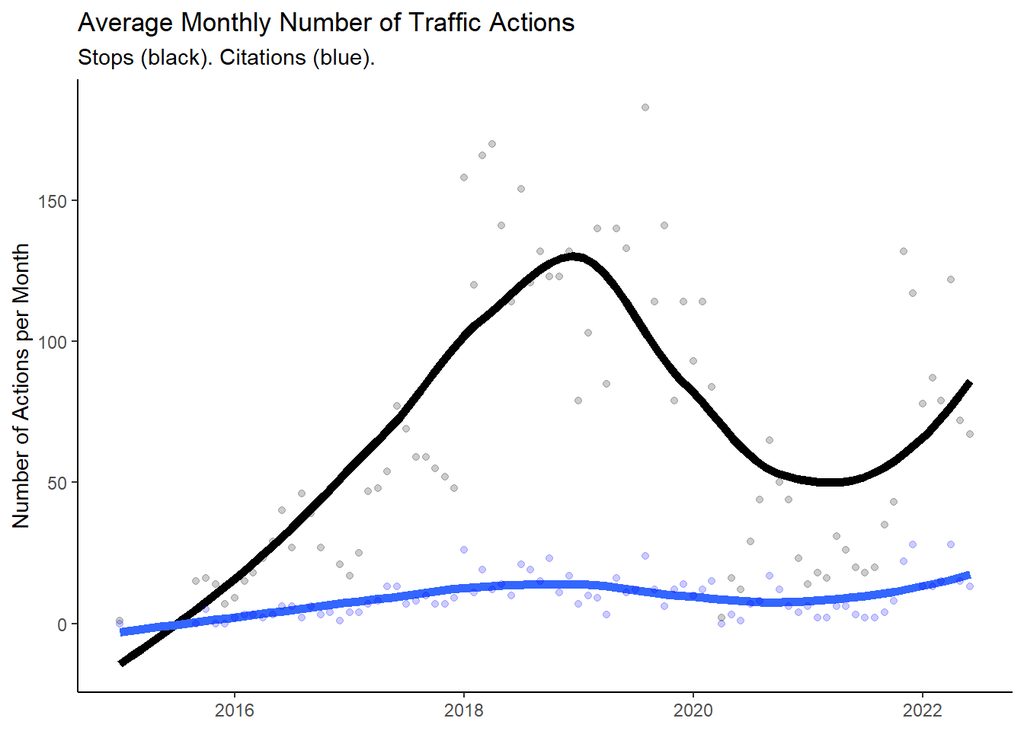

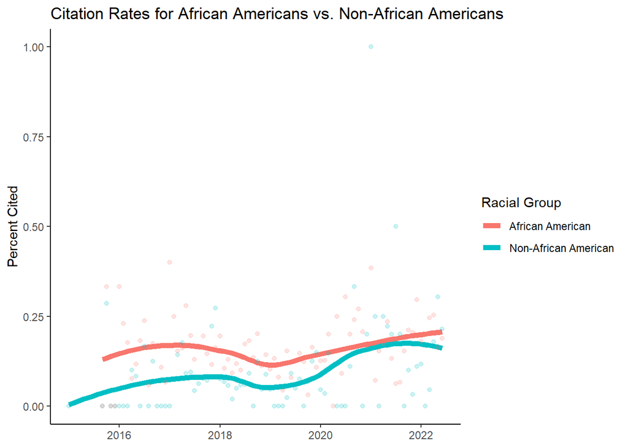

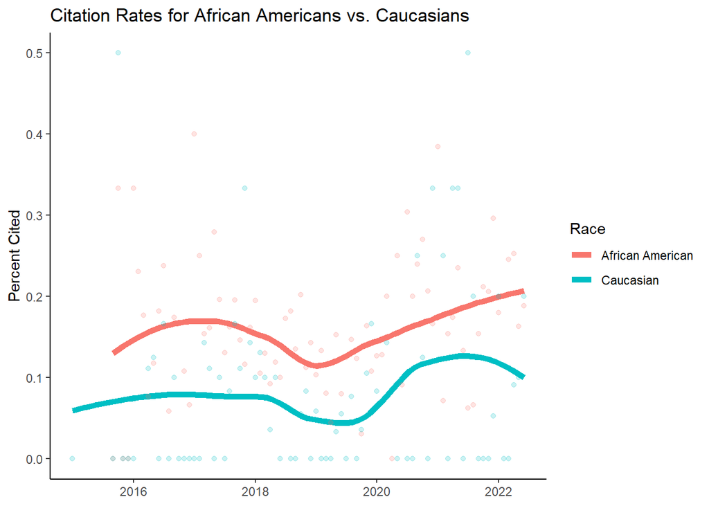

[figure not shown]

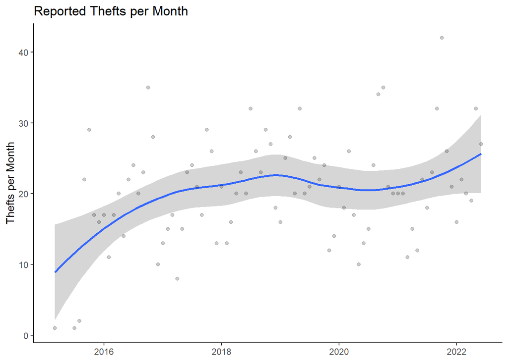

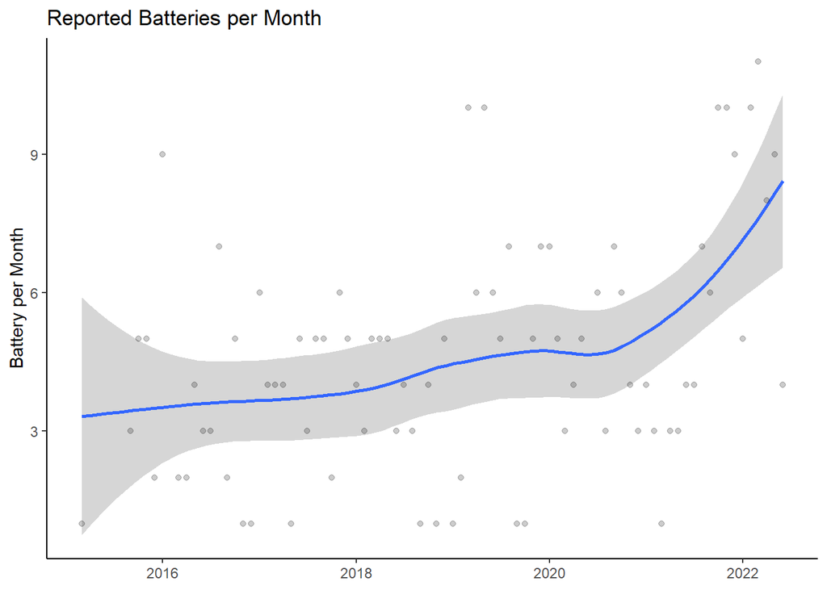

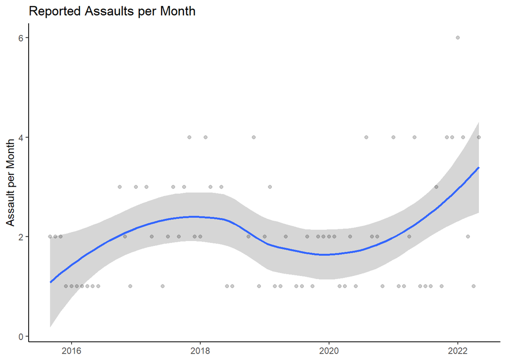

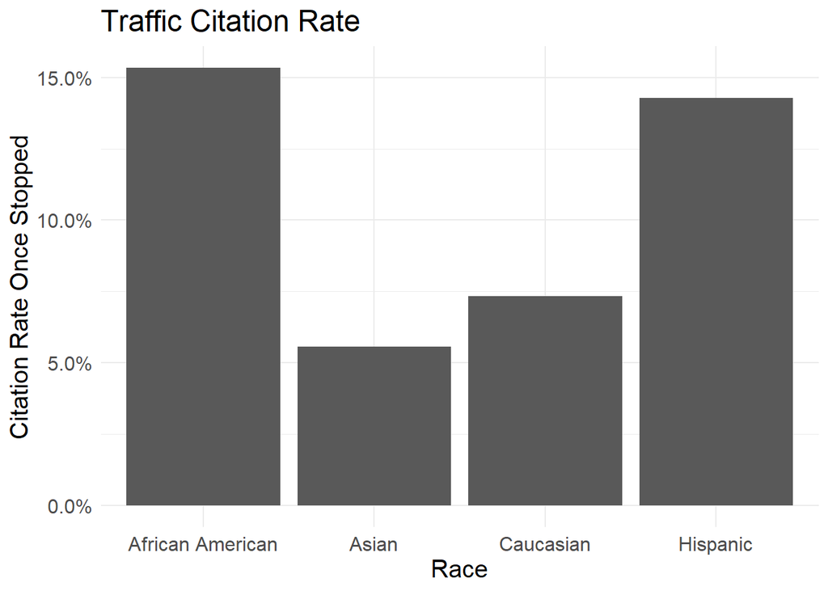

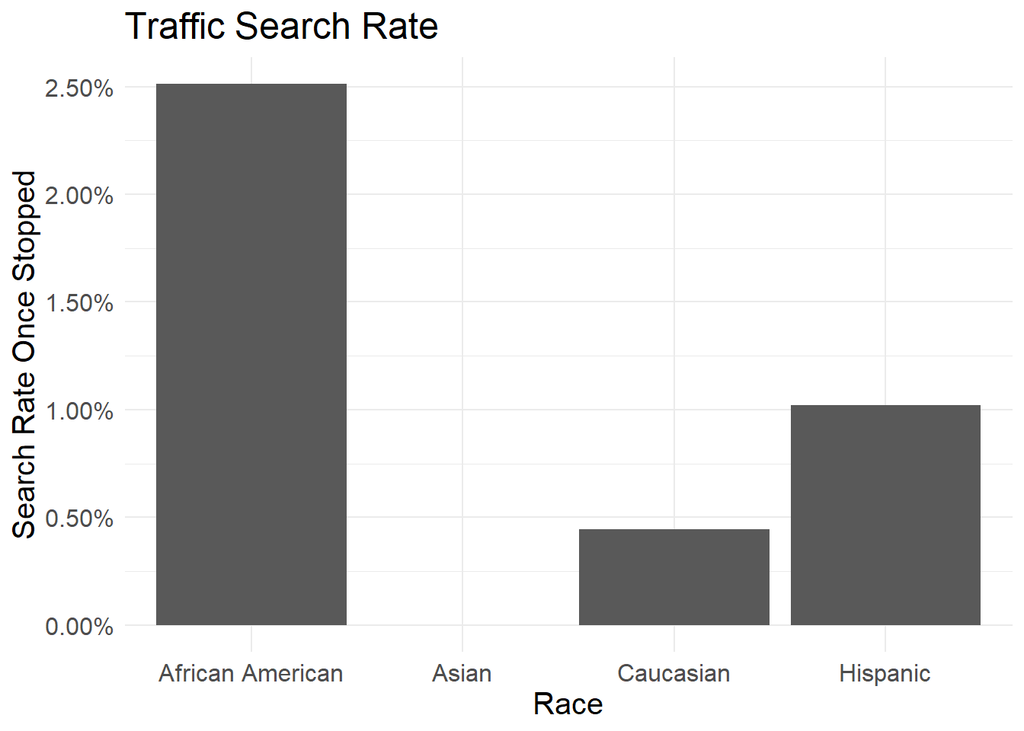

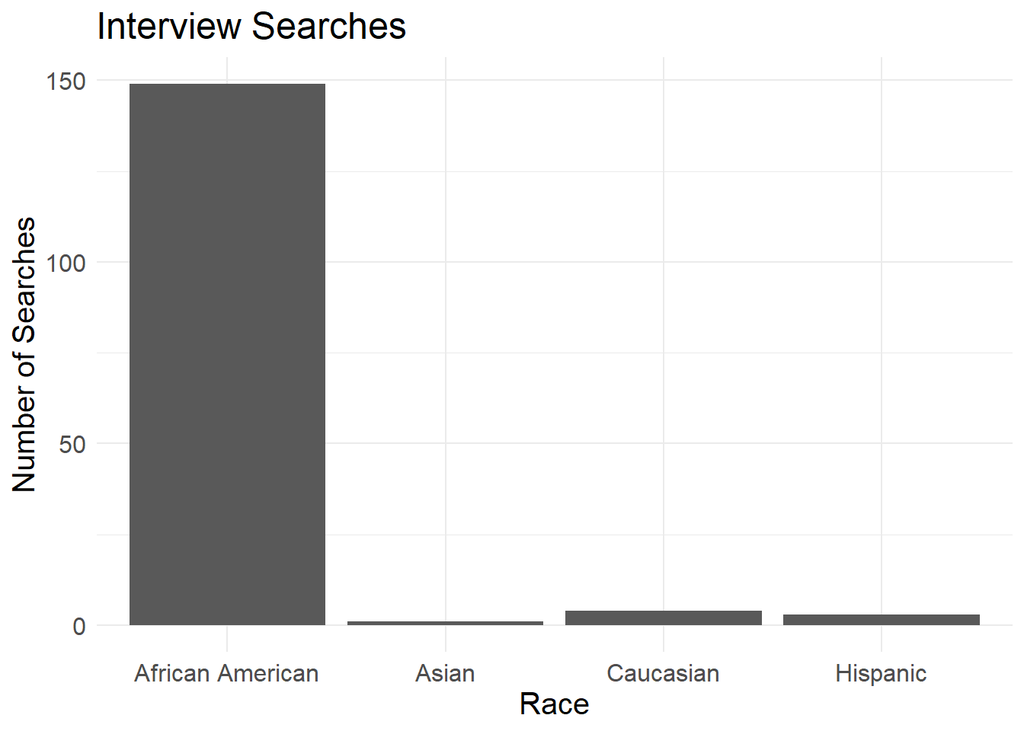

# 4 Summary Tables

## 4.1 Number of interactions with UCPD by Year

Table 1: Traffic Stops

| Year | Total | % African American |
| --- | --- | --- |
| 2015 | 53 | 69.8% |
| 2016 | 342 | 72.2% |
| 2017 | 610 | 71.1% |
| 2018 | 1654 | 72.9% |
| 2019 | 1419 | 75.1% |
| 2020 | 576 | 73.6% |
| 2021 | 490 | 75.1% |
| 2022 | 505 | 72.9% |

Table 2: Incidents

| Year | Total |
| --- | --- |
| 2015 | 337 |
| 2016 | 1097 |
| 2017 | 1105 |
| 2018 | 1247 |
| 2019 | 1228 |
| 2020 | 1169 |
| 2021 | 1273 |
| 2022 | 804 |

Table 3: Interviews

| Year | Total | % African American |
| --- | --- | --- |
| 2015 | 71 | 90.1% |
| 2016 | 77 | 88.3% |
| 2017 | 101 | 96.0% |
| 2018 | 236 | 94.1% |
| 2019 | 137 | 96.4% |
| 2020 | 68 | 92.6% |
| 2021 | 39 | 79.5% |
| 2022 | 34 | 94.1% |

## 4.2 Traffic Outcomes

Table 4: Traffic Outcomes

| Year | Citation | Warning | Arrest |
| --- | --- | --- | --- |
| 2015 | 5 | 48 | 0 |
| 2016 | 41 | 296 | 5 |
| 2017 | 97 | 512 | 1 |
| 2018 | 198 | 1456 | 0 |
| 2019 | 136 | 1283 | 0 |
| 2020 | 95 | 481 | 0 |
| 2021 | 91 | 399 | 0 |
| 2022 | 97 | 408 | 0 |

Table 5: Traffic Outcomes by Race

| Disposition | Race | Total | Share in Category |
| --- | --- | --- | --- |
| Citation | African American | 635 | 15.3% |
| Citation | Asian | 16 | 5.6% |
| Citation | Caucasian | 66 | 7.3% |
| Citation | Hispanic | 42 | 14.3% |
| Warning | African American | 3506 | 84.7% |
| Warning | Asian | 271 | 94.4% |
| Warning | Caucasian | 833 | 92.7% |
| Warning | Hispanic | 252 | 85.7% |

Table 6: Traffic Search Outcomes by Race

| Search | Race | Total | Share in Category |
| --- | --- | --- | --- |
| No | African American | 4037 | 97.5% |
| No | Asian | 287 | 100.0% |
| No | Caucasian | 895 | 99.6% |
| No | Hispanic | 291 | 99.0% |
| Yes | African American | 104 | 2.5% |
| Yes | Caucasian | 4 | 0.4% |
| Yes | Hispanic | 3 | 1.0% |

Table 7: Traffic Violation Outcomes by Race

| IDOT Classification | African American | Asian | Caucasian | Hispanic |
| --- | --- | --- | --- | --- |
| Equipment | 5.9% | 4.2% | 5.5% | 6.8% |
| Lane Violation | 19.1% | 20.9% | 25.3% | 20.4% |
| license plate/registration | 1.6% | 1.0% | 0.7% | 0.7% |
| moving violation | 9.8% | 9.8% | 10.2% | 9.2% |
| speed | 4.1% | 1.4% | 2.3% | 1.0% |
| Traffic Sign/Signal | 59.6% | 62.7% | 56.1% | 61.9% |

Table 8: Traffic Stop Outcomes by Race and Year

| Year | Race | pct_search | pct_cited | pct_search_cite | pct_search_nocite | pct_warning | count |
| --- | --- | --- | --- | --- | --- | --- | --- |
| 2015 | African American | 2.8% | 8.3% | 0% | 2.8% | 91.7% | 36 |
| 2015 | Asian | 0.0% | 0.0% | 0% | 0.0% | 100.0% | 2 |
| 2015 | Caucasian | 0.0% | 18.2% | 0% | 0.0% | 81.8% | 11 |
| 2015 | Hispanic | 0.0% | 0.0% | 0% | 0.0% | 100.0% | 2 |
| 2016 | African American | 0.41% | 14.88% | 0.41% | 0% | 85.12% | 242 |
| 2016 | Asian | 0.00% | 0.00% | 0.00% | 0% | 100.00% | 15 |
| 2016 | Caucasian | 0.00% | 6.25% | 0.00% | 0% | 93.75% | 64 |
| 2016 | Hispanic | 0.00% | 7.14% | 0.00% | 0% | 92.86% | 14 |
| 2017 | African American | 0.69% | 18.0% | 0.46% | 0.23% | 82.0% | 433 |
| 2017 | Asian | 0.00% | 6.8% | 0.00% | 0.00% | 93.2% | 44 |
| 2017 | Caucasian | 0.00% | 9.4% | 0.00% | 0.00% | 90.6% | 106 |
| 2017 | Hispanic | 4.35% | 26.1% | 4.35% | 0.00% | 73.9% | 23 |
| 2018 | African American | 2.90% | 14.2% | 1.58% | 1.3% | 85.8% | 1205 |
| 2018 | Asian | 0.00% | 0.0% | 0.00% | 0.0% | 100.0% | 87 |
| 2018 | Caucasian | 0.78% | 5.9% | 0.78% | 0.0% | 94.1% | 256 |
| 2018 | Hispanic | 0.00% | 11.9% | 0.00% | 0.0% | 88.1% | 101 |
| 2019 | African American | 3.38% | 10.8% | 1.50% | 1.9% | 89.2% | 1065 |
| 2019 | Asian | 0.00% | 6.8% | 0.00% | 0.0% | 93.2% | 59 |
| 2019 | Caucasian | 0.42% | 5.4% | 0.42% | 0.0% | 94.6% | 240 |
| 2019 | Hispanic | 0.00% | 7.8% | 0.00% | 0.0% | 92.2% | 51 |
| 2020 | African American | 4.0% | 18.6% | 3.1% | 0.94% | 81.4% | 424 |
| 2020 | Asian | 0.0% | 3.8% | 0.0% | 0.00% | 96.2% | 26 |
| 2020 | Caucasian | 0.0% | 10.5% | 0.0% | 0.00% | 89.5% | 86 |
| 2020 | Hispanic | 0.0% | 15.0% | 0.0% | 0.00% | 85.0% | 40 |
| 2021 | African American | 1.36% | 20.7% | 0.82% | 0.54% | 79.3% | 368 |
| 2021 | Asian | 0.00% | 18.2% | 0.00% | 0.00% | 81.8% | 22 |
| 2021 | Caucasian | 1.47% | 10.3% | 1.47% | 0.00% | 89.7% | 68 |
| 2021 | Hispanic | 0.00% | 13.8% | 0.00% | 0.00% | 86.2% | 29 |
| 2022 | African American | 1.6% | 20.9% | 1.6% | 0.0% | 79.1% | 368 |
| 2022 | Asian | 0.0% | 12.5% | 0.0% | 0.0% | 87.5% | 32 |
| 2022 | Caucasian | 0.0% | 8.8% | 0.0% | 0.0% | 91.2% | 68 |
| 2022 | Hispanic | 5.9% | 26.5% | 2.9% | 2.9% | 73.5% | 34 |

## 4.3 Interview Outcomes

Table 9: Interview Initiated By

| Initiated By | 2015 | 2016 | 2017 | 2018 | 2019 | 2020 | 2021 | 2022 |
| --- | --- | --- | --- | --- | --- | --- | --- | --- |
| citizen | 48 | 55 | 61 | 80 | 67 | 36 | 16 | 16 |
| UCPD | 23 | 22 | 40 | 156 | 70 | 32 | 23 | 18 |

Table 10: Interview Search Outcomes by Race

| Search | Race | Total | Share in Category |
| --- | --- | --- | --- |
| No | African American | 560 | 79.0% |
| No | Caucasian | 35 | 89.7% |
| Yes | African American | 149 | 21.0% |
| Yes | Asian | 1 | 100.0% |
| Yes | Caucasian | 4 | 10.3% |

Table 11: Interview Disposition Outcomes by Race

| Disposition | African American | Caucasian | Asian |
| --- | --- | --- | --- |
| arrested | 4.4% | 0% | NA |
| Name Checked/Other | 3.9% | 15.4% | NA |
| referred | 1.8% | 2.6% | NA |
| released | 89.8% | 82.1% | 100.0% |

## 4.4 Incident Outcomes

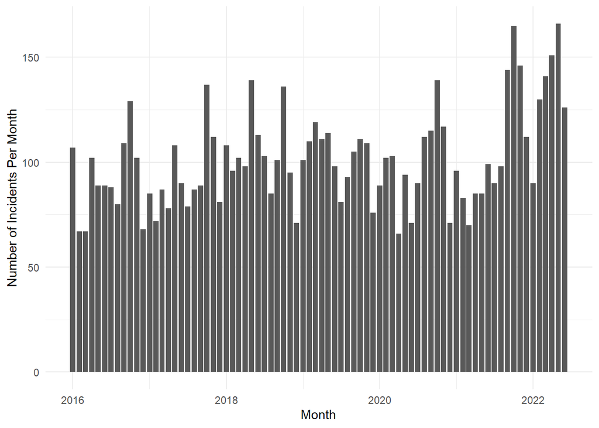

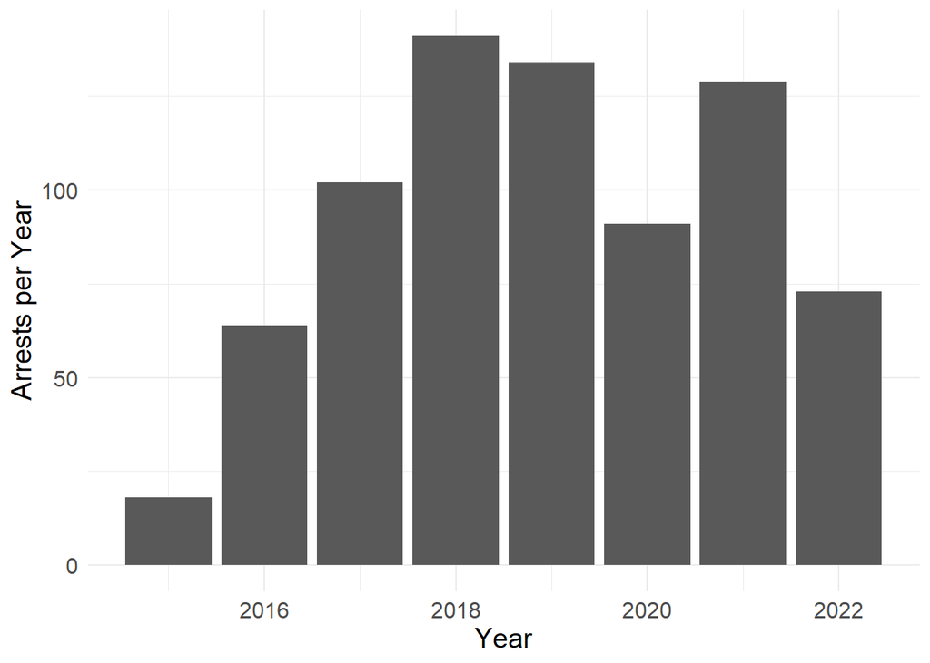

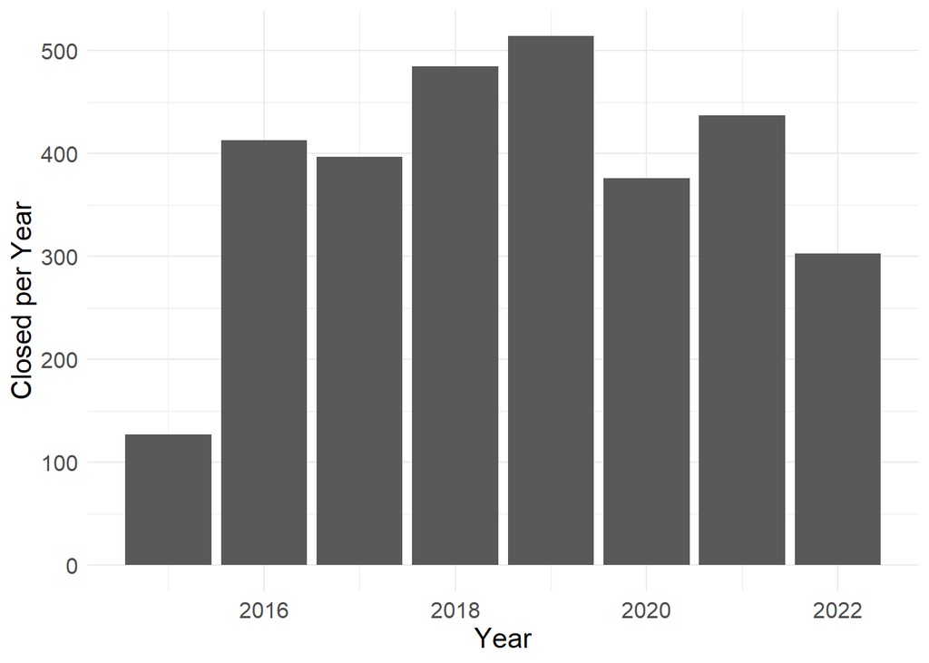

[figure not shown]

Table 12: Incident Outcomes by Year

| Year | arrested | cleared | closed | cpd | open | referred | unfounded |
| --- | --- | --- | --- | --- | --- | --- | --- |
| 2015 | 18 | 12 | 127 | 38 | 106 | 26 | 10 |
| 2016 | 64 | 24 | 413 | 268 | 233 | 76 | 19 |
| 2017 | 102 | 38 | 397 | 254 | 213 | 86 | 15 |
| 2018 | 141 | 27 | 485 | 227 | 271 | 87 | 9 |
| 2019 | 134 | 45 | 514 | 166 | 288 | 67 | 14 |
| 2020 | 91 | 33 | 376 | 425 | 169 | 69 | 6 |
| 2021 | 129 | 46 | 437 | 256 | 187 | 213 | 5 |
| 2022 | 73 | 22 | 303 | 139 | 159 | 105 | 3 |

# 5 UCPD Patrol Area

Table 13: Population in Census Tracts which intersect UCPD Patrol Area

| Total Population | Total White Population | Total Black Population |
| --- | --- | --- |
| 85477 | 21482 | 52726 |

Table 14: Projected Population in UCPD Patrol Area

| Total Population | Total White Population | Total Black Population |
| --- | --- | --- |
| 56622 | 19493 | 27524 |

[interactive chart not shown]

# 6 Github Directory

https://github.com/erhla/UCPD